# Chapter 4 In-Class R Demo: Autoregressive Models

## Demo Goal

You will see that AR models create persistence because the present depends on the past.

Reference anchor: AR stationarity, ACF decay, PACF cut-off.

```r
set.seed(311)
par(mfrow = c(1, 1))
```

## 1. AR(1) Persistence

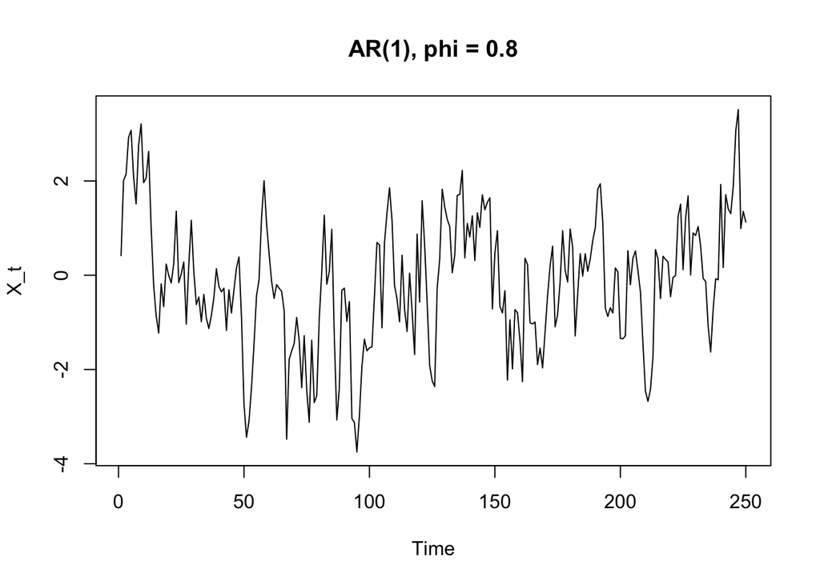

```r
phi <- 0.8
x <- arima.sim(model = list(ar = phi), n = 250)
plot.ts(x, main = paste("AR(1), phi =", phi), ylab = "X_t")
```

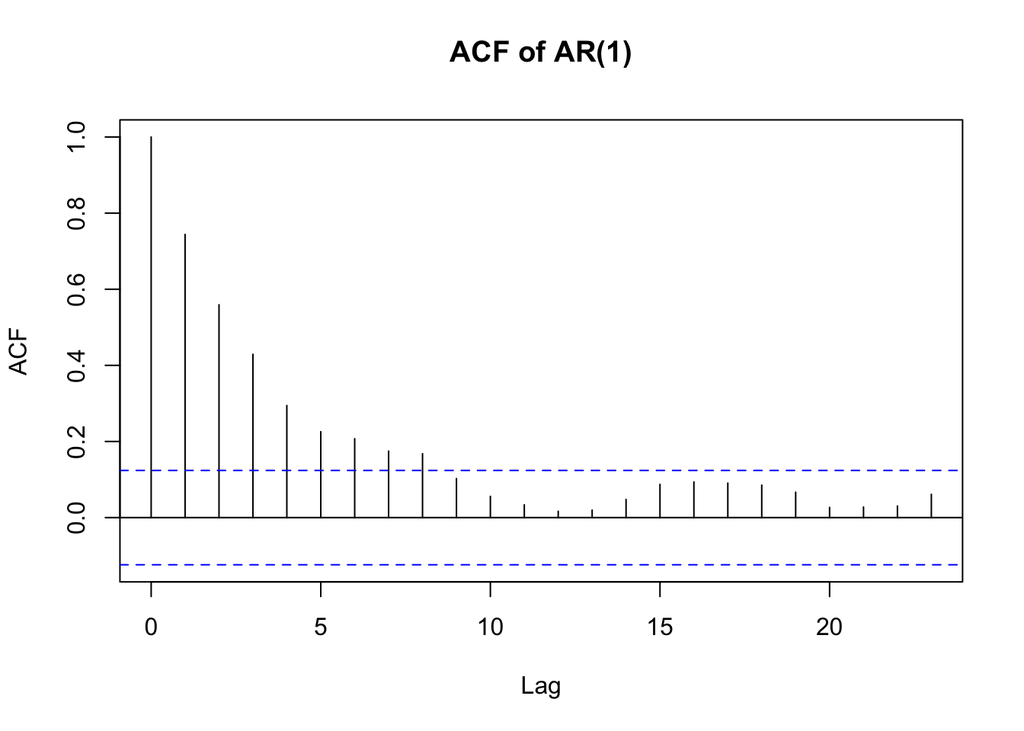

```r
acf(x, main = "ACF of AR(1)")
```

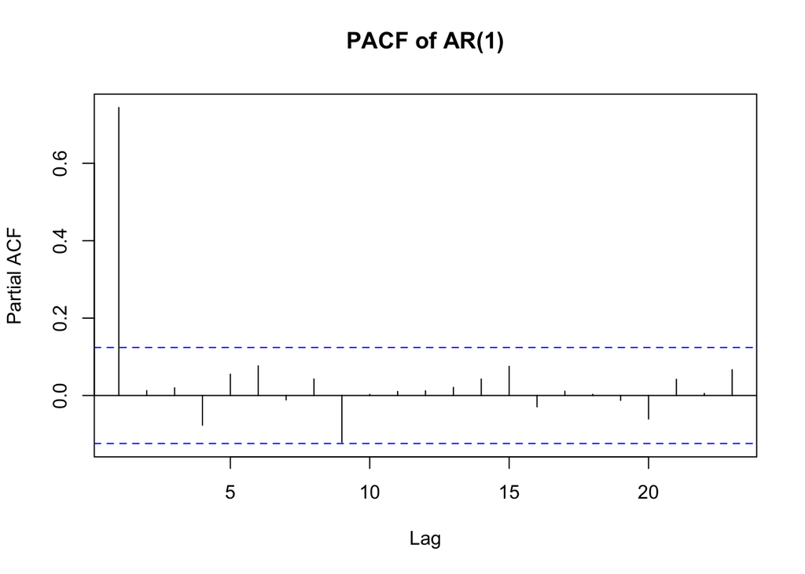

```r
pacf(x, main = "PACF of AR(1)")
```

Questions:

- Why does the ACF decay geometrically?
- Why does the PACF cut off after lag 1?

## 2. Parameter Experiment

[figure not shown]

```r
phis <- c(-0.8, 0.2, 0.8, 0.98)
par(mfrow = c(4, 2))
for (phi in phis) {
  x <- arima.sim(model = list(ar = phi), n = 250)
  plot.ts(x, main = paste("AR(1), phi =", phi), ylab = "X_t")
  acf(x, main = "ACF")
}
```

```r
par(mfrow = c(1, 1))
```

Questions:

- Which value creates slow forgetting?
- Which value creates alternating behaviour?

## 3. PACF as Direct Memory

For lag 2, the PACF removes the part of the lag 2 relationship that can already be explained by lag 1.

```r
pacf_lag2 <- function(rho1, rho2) {
  (rho2 - rho1^2) / (1 - rho1^2)
}

case_indirect <- pacf_lag2(rho1 = 0.8, rho2 = 0.64)
case_direct <- pacf_lag2(rho1 = 0.3, rho2 = 0.5)

c(
  indirect_lag2_memory = case_indirect,
  direct_lag2_memory = case_direct
)
```

```
## indirect_lag2_memory   direct_lag2_memory
##        -3.083953e-16         4.505495e-01
```

Questions:

- In the first case, why is PACF lag 2 equal to zero?
- In the second case, why might AR(2) be worth trying?

Compare with a simulated AR(1) series.

```r
x_ar1 <- arima.sim(model = list(ar = 0.8), n = 500)
acf_values <- acf(x_ar1, plot = FALSE)$acf[1:4]
pacf_values <- pacf(x_ar1, plot = FALSE)$acf[1:3]

data.frame(
  lag = 1:3,
  acf = round(acf_values[2:4], 3),
  pacf = round(pacf_values, 3)
)
```

```
##   lag   acf   pacf
## 1   1 0.788  0.788
## 2   2 0.639  0.046
## 3   3 0.503 -0.037
```

The ACF still shows lag 2 and lag 3 correlation, but the PACF should be much smaller after lag 1.

### What the Lag-2 PACF Measures

For the AR(1) with $\phi = 0.8$, $\rho(2) = 0.64$ but $\phi_{22} = 0$. $X_{t-2}$ is related to $X_t$ only through $X_{t-1}$. To see this, remove the linear effect of $X_{t-1}$ from both $X_t$ and $X_{t-2}$ by least squares,

$$U_t = X_t - \hat a - \hat b X_{t-1}, \qquad
V_t = X_{t-2} - \hat c - \hat d X_{t-1},$$

and correlate what is left: $\phi_{22} = \operatorname{Corr}(U_t, V_t)$. This is not $\rho(2) - \rho(1)$: both variables are adjusted before the correlation is taken.

```r
pacf2_by_regression <- function(x, label) {
  x <- as.numeric(x)
  n <- length(x)
  d <- data.frame(xt  = x[3:n],         # X_t
                  xt1 = x[2:(n - 1)],   # X_{t-1}
                  xt2 = x[1:(n - 2)])   # X_{t-2}

  fit_u <- lm(xt ~ xt1, data = d)       # X_t explained by X_{t-1}
  fit_v <- lm(xt2 ~ xt1, data = d)      # X_{t-2} explained by X_{t-1}
  d$u <- residuals(fit_u)               # what X_{t-1} cannot explain in X_t
  d$v <- residuals(fit_v)               # ... and in X_{t-2}

  r_acf  <- cor(d$xt, d$xt2)
  r_pacf <- cor(d$u, d$v)
  pts <- rgb(0, 0, 1, 0.2)

  par(mfrow = c(2, 2))
  plot(d$xt2, d$xt, pch = 16, col = pts, xlab = "X_(t-2)", ylab = "X_t",
       main = paste0(label, ": X_t vs X_(t-2), r = ", round(r_acf, 3)))
  abline(lm(xt ~ xt2, data = d), col = "red", lwd = 2)
  plot(d$xt1, d$xt, pch = 16, col = pts, xlab = "X_(t-1)", ylab = "X_t",
       main = "Step 1: X_t on X_(t-1)")
  abline(fit_u, col = "red", lwd = 2)
  plot(d$xt1, d$xt2, pch = 16, col = pts, xlab = "X_(t-1)", ylab = "X_(t-2)",
       main = "Step 2: X_(t-2) on X_(t-1)")
  abline(fit_v, col = "red", lwd = 2)
  plot(d$v, d$u, pch = 16, col = rgb(0, 0.5, 0, 0.2),
       xlab = "V (residual of X_(t-2))", ylab = "U (residual of X_t)",
       main = paste0("Residuals: r = ", round(r_pacf, 3)))
  abline(lm(u ~ v, data = d), col = "red", lwd = 2)
  par(mfrow = c(1, 1))

  round(c(
    acf2_from_pairs     = r_acf,
    acf2_from_acf       = acf(x, plot = FALSE)$acf[3],
    pacf2_from_resid    = r_pacf,
    pacf2_from_pacf     = pacf(x, plot = FALSE)$acf[2],
    coef_xt2_in_ar2_fit = unname(coef(lm(xt ~ xt1 + xt2, data = d))["xt2"])
  ), 3)
}
```

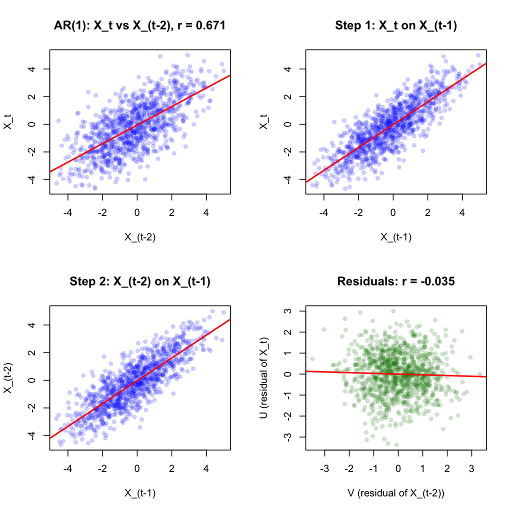

```
##     acf2_from_pairs       acf2_from_acf    pacf2_from_resid     pacf2_from_pacf
##               0.671               0.671              -0.035              -0.035
## coef_xt2_in_ar2_fit
##              -0.035
```

```r
x_ar1 <- arima.sim(model = list(ar = 0.8), n = 1000)
pacf2_by_regression(x_ar1, "AR(1)")
```

`pacf()` computes the same quantity from the sample ACF (Durbin–Levinson recursion), so the two values agree closely but not exactly. The slope of the red line in the residual plot equals the coefficient of $X_{t-2}$ when $X_t$ is regressed on both $X_{t-1}$ and $X_{t-2}$: the lag-2 PACF is the last coefficient of a fitted AR(2).

Questions:

- In the first plot, $X_{t-2}$ clearly helps to predict $X_t$. Why?
- Why do we remove $X_{t-1}$ from both $X_t$ and $X_{t-2}$, not only from $X_t$?
- Once you know $X_{t-1}$, does $X_{t-2}$ tell you anything more about $X_t$?

Now an AR(2), $X_t = 0.6X_{t-1} + 0.2X_{t-2} + \epsilon_t$, which has almost the same lag-2 autocorrelation.

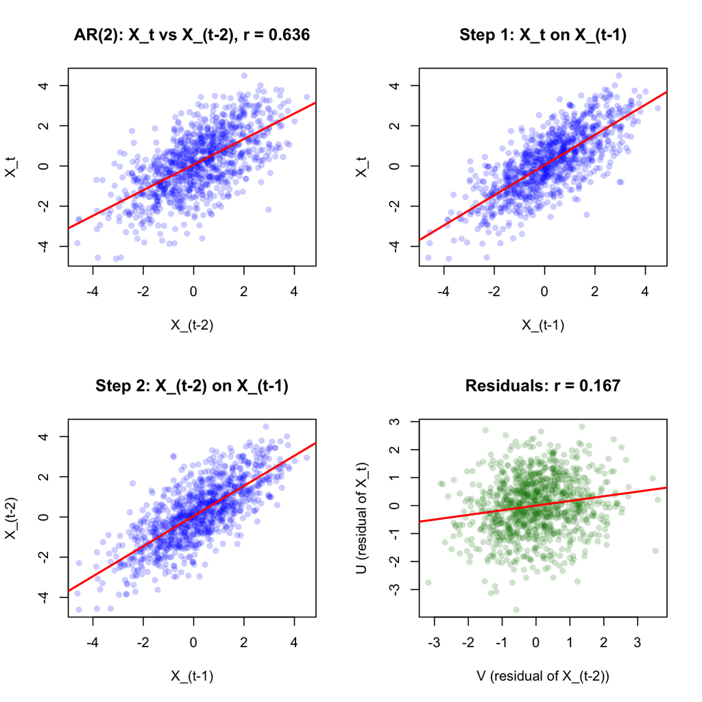

```
##     acf2_from_pairs       acf2_from_acf    pacf2_from_resid     pacf2_from_pacf
##               0.636               0.635               0.167               0.164
## coef_xt2_in_ar2_fit
##               0.167
```

```r
x_ar2 <- arima.sim(model = list(ar = c(0.6, 0.2)), n = 1000)
pacf2_by_regression(x_ar2, "AR(2)")
```

```r
# Theoretical values
data.frame(
  model = c("AR(1), phi = 0.8", "AR(2), phi = (0.6, 0.2)"),
  acf2  = c(ARMAacf(ar = 0.8, lag.max = 2)[3],
            ARMAacf(ar = c(0.6, 0.2), lag.max = 2)[3]),
  pacf2 = c(ARMAacf(ar = 0.8, lag.max = 2, pacf = TRUE)[2],
            ARMAacf(ar = c(0.6, 0.2), lag.max = 2, pacf = TRUE)[2]),
  row.names = NULL
)
```

```
##                     model acf2        pacf2
## 1        AR(1), phi = 0.8 0.64 1.480297e-16
## 2 AR(2), phi = (0.6, 0.2) 0.65 2.000000e-01
```

Questions:

- The two models have $\rho(2) = 0.64$ and $0.65$. Which plot tells them apart?
- Why is $\phi_{22} = \phi_2 = 0.2$ for this AR(2)?
- The sample ACF at lag 2 can differ from $0.64$ or $0.65$ by several hundredths. Why is it hard to tell the two models apart from the ACF alone?

Try it yourself:

- Change $\phi_2$ to $0$ or $-0.3$ (keep $\phi_1 = 0.6$) and rerun. How do the first and last plots change?

## 4. AR(2) Oscillation

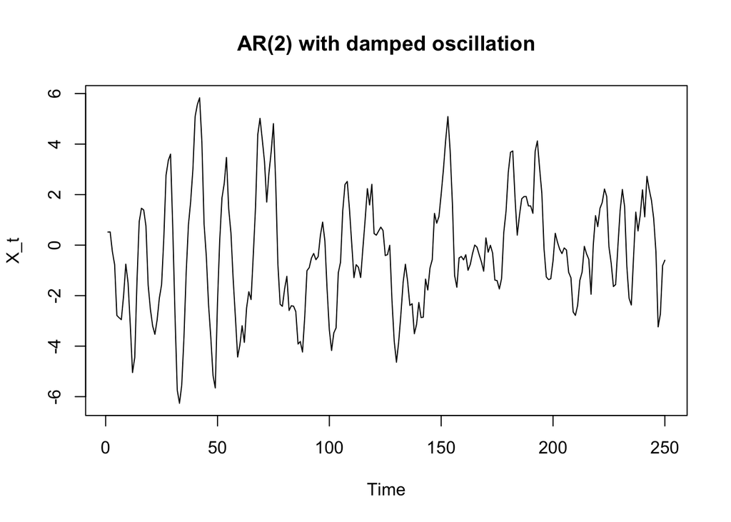

```r
x <- arima.sim(model = list(ar = c(1.3, -0.5)), n = 250)
plot.ts(x, main = "AR(2) with damped oscillation", ylab = "X_t")
```

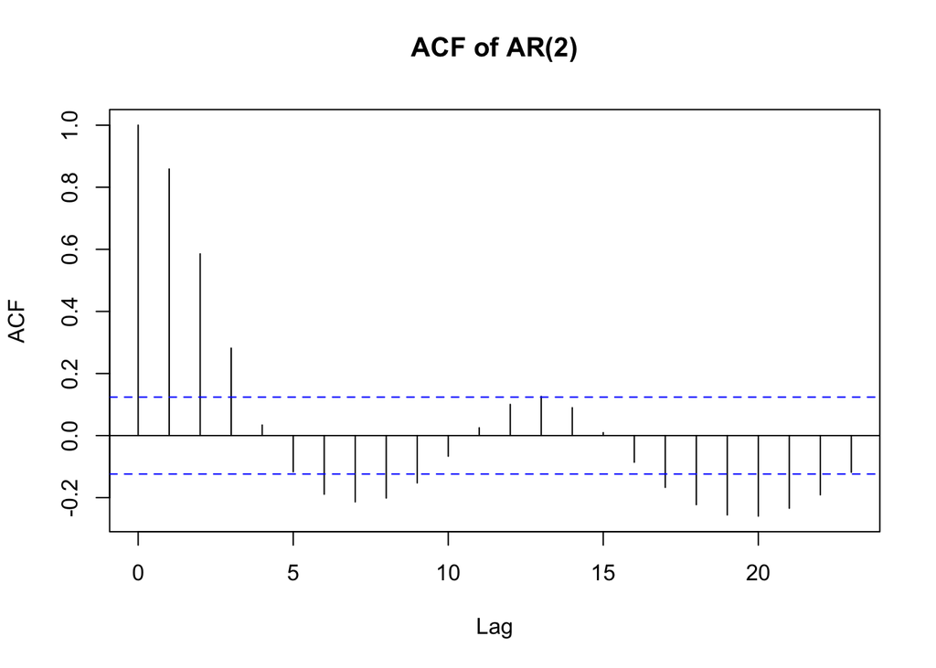

```r
acf(x, main = "ACF of AR(2)")
```

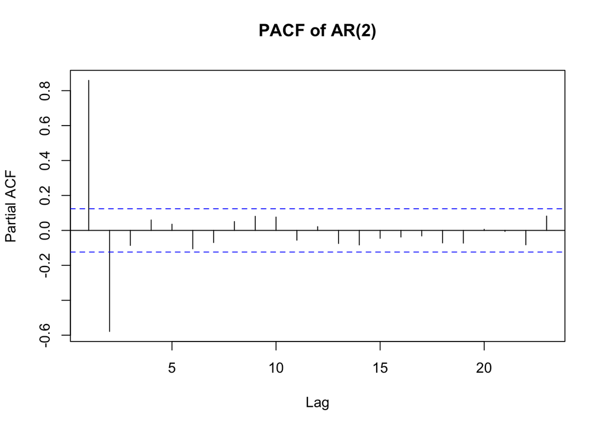

```r
pacf(x, main = "PACF of AR(2)")
```

Try it yourself:

- Change the AR coefficients.
- When does the series become unstable or start to explode?

`arima.sim()` refuses non-stationary coefficients, so check the roots of $\phi(z) = 1 - \phi_1 z - \phi_2 z^2$ first and use `filter()` to see what happens outside the stationarity triangle.

```r
Mod(polyroot(c(1, -1.3, 0.5)))   # both > 1: stationary
```

```
## [1] 1.414214 1.414214
```

```r
Mod(polyroot(c(1, -0.5, -0.6)))  # one < 1: not stationary
```

```
## [1] 0.9399017 1.7732350
```

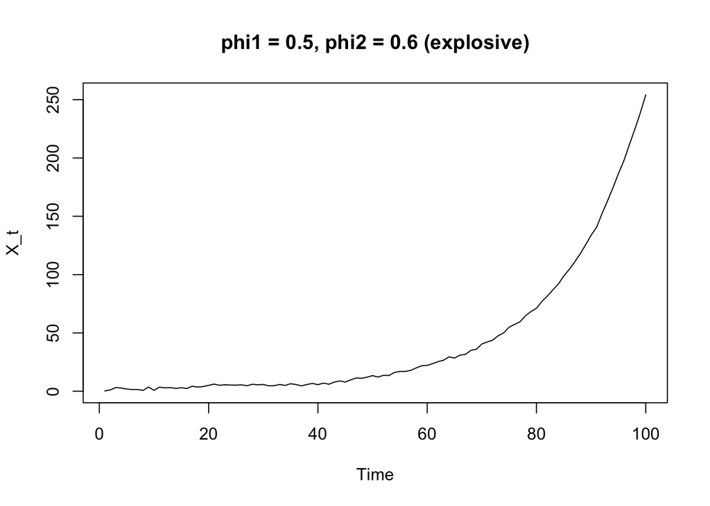

```r
# X_t = 0.5 X_{t-1} + 0.6 X_{t-2} + eps_t, started at zero
x_bad <- filter(rnorm(100), c(0.5, 0.6), method = "recursive")
plot.ts(x_bad, main = "phi1 = 0.5, phi2 = 0.6 (explosive)", ylab = "X_t")
```

## 5. Fitting and Forecasting: Lake Huron

The notes fit an AR(2) to the annual level of Lake Huron (`LakeHuron`, feet).

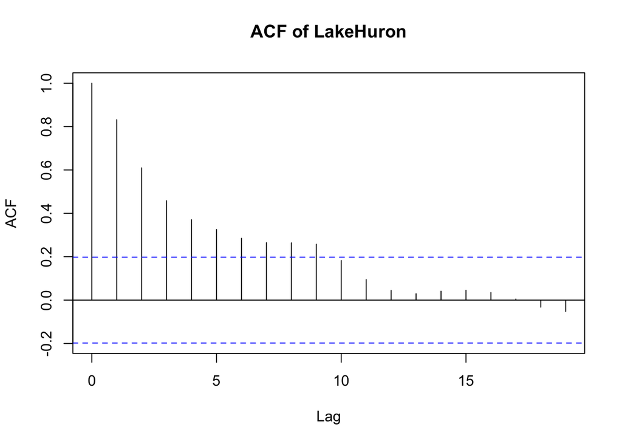

```r
acf(LakeHuron, main = "ACF of LakeHuron")
```

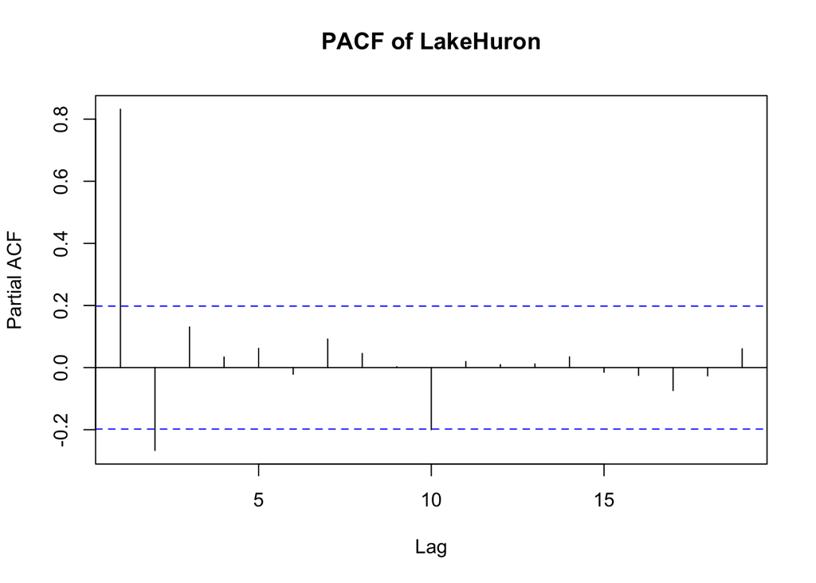

```r
pacf(LakeHuron, main = "PACF of LakeHuron")
```

```r
fit <- arima(LakeHuron, order = c(2, 0, 0))
fit                               # 'intercept' is the mean mu
```

```
##
## Call:
## arima(x = LakeHuron, order = c(2, 0, 0))
##
## Coefficients:
##          ar1      ar2  intercept
##       1.0436  -0.2495   579.0473
## s.e.  0.0983   0.1008     0.3319
##
## sigma^2 estimated as 0.4788:  log likelihood = -103.63,  aic = 215.27
```

```r
Box.test(residuals(fit), lag = 12, type = "Ljung-Box", fitdf = 2)
```

```
##
##  Box-Ljung test
##
## data:  residuals(fit)
## X-squared = 7.0977, df = 10, p-value = 0.7162
```

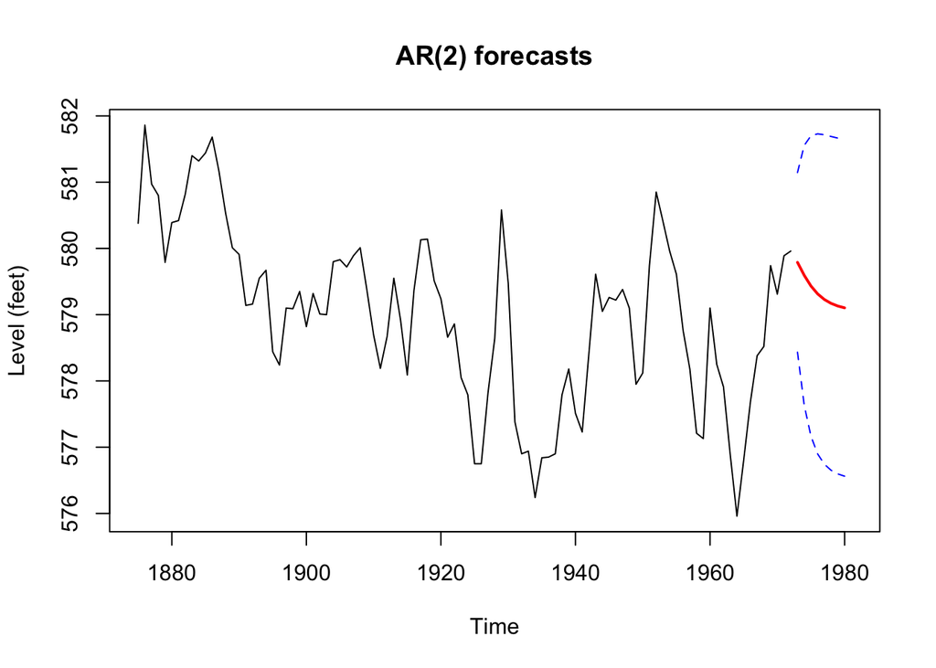

```r
fc <- predict(fit, n.ahead = 8)
plot(LakeHuron, xlim = c(1875, 1981),
     ylim = range(LakeHuron, fc$pred + 1.96 * fc$se, fc$pred - 1.96 * fc$se),
     main = "AR(2) forecasts", ylab = "Level (feet)")
lines(fc$pred, col = "red", lwd = 2)
lines(fc$pred + 1.96 * fc$se, col = "blue", lty = 2)
lines(fc$pred - 1.96 * fc$se, col = "blue", lty = 2)
```

Questions:

- Which features of the ACF and PACF point to an AR(2)?
- Why is `fitdf = 2` used in the Ljung–Box test?
- Where do the forecasts go as the horizon grows, and why do the intervals stop widening?